# REPORT

## 1. Introduction

In 2016, the great human player lost to Alphago in a Go game. In the last few days, the Go player, who lost to Alphago, has been playing his last retirement match against another AI. The era of reinforcement learning is likely to open soon. It could be applied in almost everywhere. Over the past month, I have studied the basics of deep reinforcement learning in Udacity. As unsupervised learning, it learns through interaction with the environment.This is an amazing algorithm. Didn't millions of images be needed to distinguish dogs and cats? I did this project using all the knowledge and code I learned in the lecture. Project in the Unity environment was fun. Let's look at the algorithm used to solve the problems.

## 2. Main

When I just started this project, I applied DQN. After verifying that the code works well in the unity environment, I tried to improve the performance by using Dueling Network and DDQN.

### 2.1. Dueling Network

Introducing Deuling Network. Look at the picture below. The right side of the figure is A(s, *) = Q(s,* ) - V(s), which is advantage funtion.

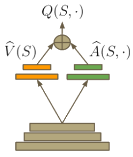

(source from torch.ch)

V (s) and A (s, a) are arranged below the output layer of Q (s,). It is possible to learn V (S) which is determined only by the state without relying on the actions, thereby improving the training performance.

I have improved the DQN neural network as below.

*For instance,* *Q(s, a1) = V(s) + Adv(s,a1) - (Adv(s,a1) + Adv(s,a2) + Adv(s,a3) + Adv(s,a4) / 4*

```python
# This hiddenlayer divided into two
self.fc4_adv = nn.Linear(fc3_units, action_size) # Advantage part
self.fc4_v = nn.Linear(fc3_units, 1) # V(s)

# Advantage function
adv = self.fc4_adv(x)
# V(s)
val = self.fc4_v(x).expand(-1, adv.size(1))

# V(s) +  Advantage - Average(Advantage)
output = val + adv - adv.mean(1, keepdim=True).expand(-1, adv.size(1))
```

### 2.2. DDQN

DQN often overestimates the maximum-value of Q value since DQN uses max_Q(S, A) in the target. A technique designed to reduce this overestimation is known as *DDQN*.

In the next code cell, I wrote the above formula in code. There are two networks used for training. In the Agent Class, these are the *qnetwork_target* and *qnetwork_local* . In the next state, the maximum action is obtained from *qnetwork_local*, and the Q-value at this time-step is come from *qnetwork_target*.

```python
# Get action maximizing Q values from local network
max_actions = self.qnetwork_local(next_states).max(1)[1].unsqueeze(1)

# Get Q values from target network for next state
TargetQnext = self.qnetwork_target(next_states).detach().gather(1, max_actions)

# Compute Q values as targets
TargetQ = rewards + (gamma * TargetQnext * (1 - dones))

# Get expected Q values from local_network
ExpectedQ = self.qnetwork_local(states).gather(1, actions)

# Compute loss
Loss = F.mse_loss(ExpectedQ, TargetQ)
```

### 2.3. Experience Replay

**Experience Replay** is to store in replay memory the experiences that agents gain from exploring in the environment. As the agent learns, it randomly takes several samples from this memory and updates the neural network. So,it can eliminate the correlation between samples. If a SARSA agent is trapped between a green banana and a wall, it will be trained for that situation, and it will never escape from bad situation.

We can solve this problem by using Experience Replay. This is because the samples used for learning do not have a time correlation like On-policy algorithm. In addition, the training is stable because the neural network is updated through several samples extracted from replay memory. In this project, I used the proven ReplayBuffer class.

## 3. Result

DQN

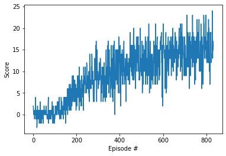

Dueling DDQN

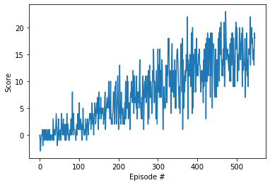

The picture above is **DQN**, and the goal was reached in the 733th episode. You can see the training slows down around 300 episodes. It shows the typical disadvantage of DQN overestimates the maximum of Q. To solve this problem, Dueling network and DDQN are applied in this project.

The graph below is a **Dueling DDQN**, the model I used. As the episode progresses, you can see it rising to the right close to the direct proportion. This means that the agent is not congested and is learning at a fast pace.

Reached the project goal in the *447th episode*. This is a *39%* increase in efficiency!

## 4. Future improvements

- This model could be better with Prioritized Experience Replay.
- Applying deeper neural networks, performance is likely to be upgraded.
- CNN can be applied for optional project 'Navigation_pixels.ipynb'
- Recently, I read about the world model on Gym. I want to implement it in unity.

Thank you for reading.